# Oral Maxillofacial Surgery Location Analysis

Optima Location Solutions ©

April 30, 2020

## **Provo Office**

#### 777 N 500 W Suite 102

#### Provo, UT

[figure not shown]

Click [here](https://drive.google.com/open?id=1Gqt0UXunp4B-GbMrRVlkEZEbA0wfSHOM&usp=sharing) for interactive map.

### Location Summary

The defining feature of the Provo location is its proximity to Brigham Young University. Demographics, incomes, and age distributions all point to a population largely consisting of young, low-income, college students. This is also evident in the low school concentration and high median age (relatively few children) of the population. While these factors do not typically suggest a strong market for dental professionals, the high population to oral surgeon ratio and dense concentration of other dental offices (strong referring potential) modestly compensate for weaker indicators. While our models suggest that market demand within Provo itself is already met, demand from the Orem area and southern Provo/Springville can support 1-2 additional oral surgeons. However, modest growth projections suggest only a mild increase in demand over the next 5 years.

**Traffic Count: 35,000 vehicles/day**

### Notable Demographic Distributions

#### 5 mile radius

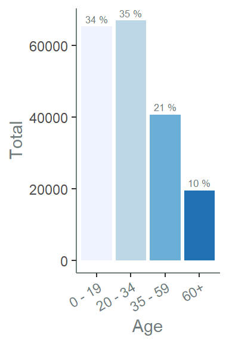

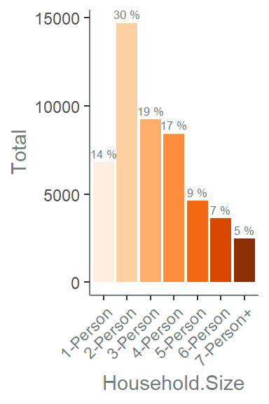

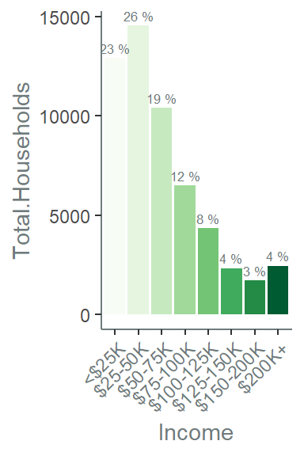

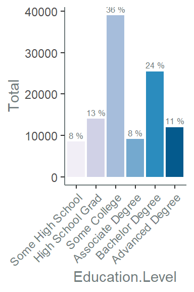

### Concentric Ring Comparisons

##### Demographics

|  | 1 Mile | 3 Mile | 5 Mile |
| --- | --- | --- | --- |
| Population | 40,773.0 | 137,065.0 | 192,344.0 |
| Population Growth Rate 2019-2024 | 10.67% | 9.97% | 9.92% |
| Households | 11,776 | 39,075 | 55,166 |
| Household Growth Rate 2019-2024 | 11.03% | 10.24% | 10.12% |
| Average Household Size | 3.1 | 3.2 | 3.2 |
| Median Household Income | $33,094 | $44,194 | $50,317 |
| Median Age | 25 | 25.3 | 25.6 |

##### Businesses & Schools

|  | 1 Mile | 3 Mile | 5 Mile |
| --- | --- | --- | --- |
| Number of Business (1 mile only) | 1,984 |  |  |
| Elementary Schools | 1 | 14 | 25 |
| Middle Schools | 1 | 2 | 4 |
| High Schools | 1 | 4 | 8 |
| Hospitals (Current & Announced) | 1 | 2 | 5 |

##### Dental Market

|  | 1 Mile | 3 Mile | 5 Mile |
| --- | --- | --- | --- |
| General Dentists | 10 | 65 | 94 |
| Orthodontists | 0 | 4 | 8 |
| Pediatric Dentists | 3 | 4 | 5 |
| Endodontists | 0 | 2 | 3 |
| Periodontists | 2 | 4 | 6 |
| Prosthodontists | 0 | 1 | 2 |
| Total Dental Professionals | 17 | 83 | 122 |

##### Oral Surgeon Market

|  | 1 Mile | 3 Mile | 5 Mile |
| --- | --- | --- | --- |
| Population/Oral Surgeon Ratio | 20,386.0 | 45,688.0 | 48,086.0 |
| Current Oral Surgeons | 2 | 3 | 4 |
| Estimated Demand† | 1.4 | 3.8 | 6.2 |
| Projected 5 Year Demand | 1.4 | 4.1 | 6.7 |

### Notable Demographic Comparisons

#### 5 mile radius

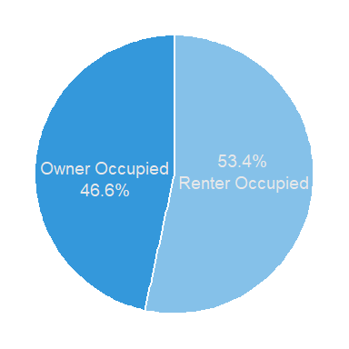

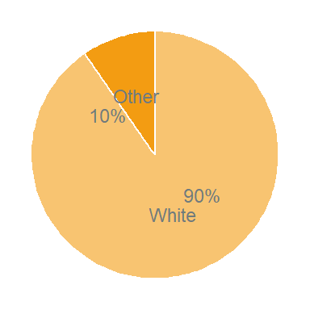

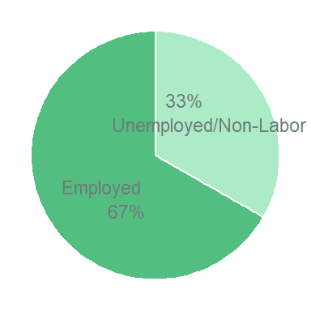

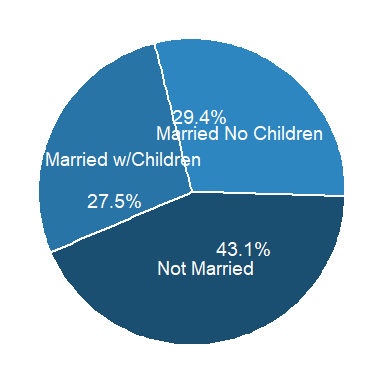

†See *About Our Analysis Process* for details on how demand is calculated.

## **American Fork Office**

#### 1022 E 220 S Bamberger Dr

#### American Fork, UT

[figure not shown]

Click [here](https://drive.google.com/open?id=1Gqt0UXunp4B-GbMrRVlkEZEbA0wfSHOM&usp=sharing) for interactive map.

### Location Summary

The American Fork location shows evidence of a dual population. Age distributions suggest a notable population of students, likely due to the proximity to Utah Valley University, and a substantial segment of working professionals with higher incomes and larger families. Population density appears to be far lower than in Provo, but is offset by higher growth rates and a higher concentration of dental professionals indicating strong referring potential. Though population to oral surgeon ratios are lower than in Provo, higher growth, larger incomes, more families, and a higher concentration of schools suggest a healthy market within American Fork, Pleasant Grove, and Cedar Hills. Our models estimate sufficient demand to support up to 3 additional oral surgeons in that immediate market with the caveat that the presence of several competitors in Lindon, Lehi, and Highland suggest that demand has already been met in surrounding cities. Growth rates are modest but not neglible. We expect demand to increase by about half an oral surgeon over the next 5 years.

**Traffic Count: 14,000 vehicles/day**

### Notable Demographic Distributions

#### 5 mile radius

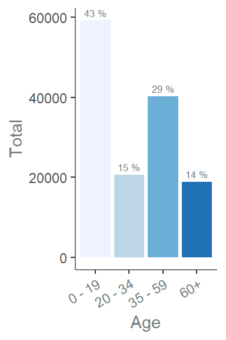

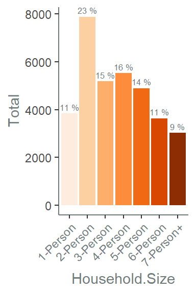

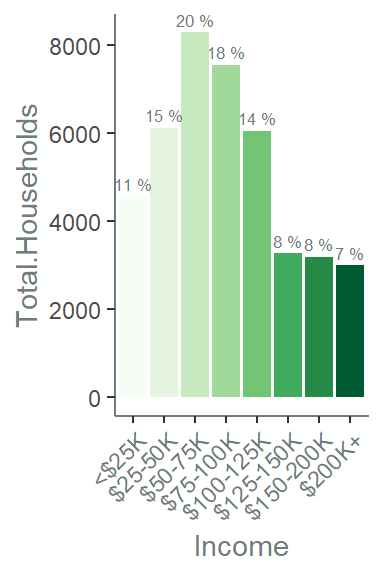

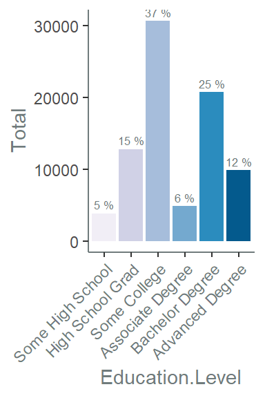

### Concentric Ring Comparisons

##### Demographics

|  | 1 Mile | 3 Mile | 5 Mile |
| --- | --- | --- | --- |
| Population | 14,025.0 | 77,071.0 | 156,031.0 |
| Population Growth Rate 2019-2024 | 11.12% | 11.24% | 11.51% |
| Households | 4,400 | 21,317 | 42,041 |
| Household Growth Rate 2019-2024 | 11.2% | 11.26% | 11.66% |
| Average Household Size | 3.1 | 3.5 | 3.7 |
| Median Household Income | $63,320 | $71,070 | $81,755 |
| Median Age | 25.3 | 25.2 | 25 |

##### Businesses & Schools

|  | 1 Mile | 3 Mile | 5 Mile |
| --- | --- | --- | --- |
| Number of Business (1 mile only) | 864 |  |  |
| Elementary Schools | 2 | 14 | 23 |
| Middle Schools | 0 | 2 | 3 |
| High Schools | 1 | 4 | 5 |
| Hospitals (Current & Announced) | 1 | 1 | 2 |

##### Dental Market

|  | 1 Mile | 3 Mile | 5 Mile |
| --- | --- | --- | --- |
| General Dentists | 20 | 54 | 82 |
| Orthodontists | 6 | 9 | 19 |
| Pediatric Dentists | 10 | 10 | 15 |
| Endodontists | 0 | 1 | 1 |
| Periodontists | 1 | 1 | 1 |
| Prosthodontists | 1 | 1 | 1 |
| Total Dental Professionals | 40 | 78 | 125 |

##### Oral Surgeon Market

|  | 1 Mile | 3 Mile | 5 Mile |
| --- | --- | --- | --- |
| Population/Oral Surgeon Ratio | 7,012.0 | 38,536.0 | 26,005.0 |
| Current Oral Surgeons | 2 | 2 | 6 |
| Estimated Demand† | 3.1 | 5.2 | 6.4 |
| Projected 5 Year Demand | 3.2 | 5.6 | 7 |

### Notable Demographic Comparisons

#### 5 mile radius

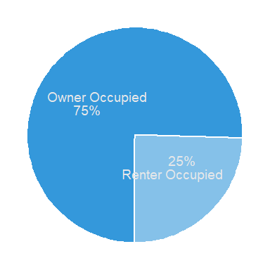

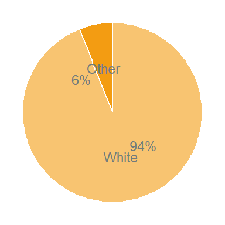

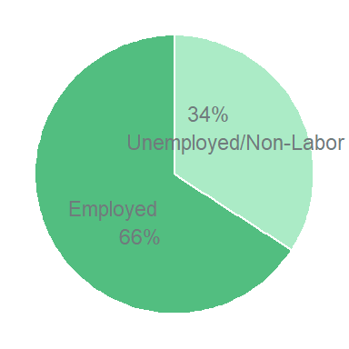

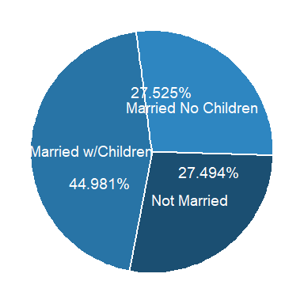

†See *About Our Analysis Process* for details on how demand is calculated.

## **Saratoga Springs Office**

#### 2070 N Redwood Rd

#### Saratoga Springs, UT

[figure not shown]

Click [here](https://drive.google.com/open?id=1Gqt0UXunp4B-GbMrRVlkEZEbA0wfSHOM&usp=sharing) for interactive map.

### Location Summary

Saratoga Springs presents a unique challenge for modeling market demand. In addition to 1 mile, 3 mile, and 5 mile rings, we have also considered demand & growth coming from southern Saratoga Springs and Eagle Mountain. The lack of competitors, high growth, and daily commutes from these areas lead us to believe that they will likely be served by dental professionals in northern Saratoga Springs and Lehi. Our models suggest that, due to low population density and a low concentration of dental professionals to refer oral surgeons, the immediate areas surrounding the Saratoga Springs location have low demand and too many competitors. However, Eagle Mountain and southern Saratoga Springs offer few competitors, high growth, high incomes, a high concentration of schools for young families, and a high population to oral surgeon ratio. When these areas are considered as part of the market for this location, we see immediate demand for at least 1 additional oral surgeon and projected demand for up to 4 additional surgeons in the next 5 years.

**Traffic Count: 24,000 vehicles/day**

### Notable Demographic Distributions

#### 5 mile radius

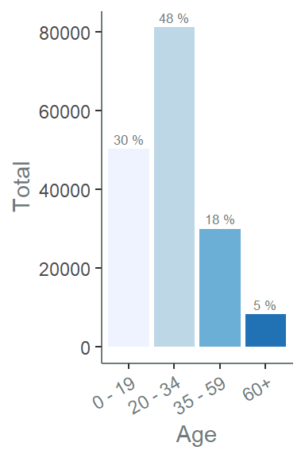

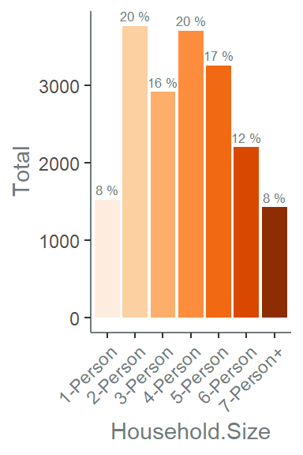

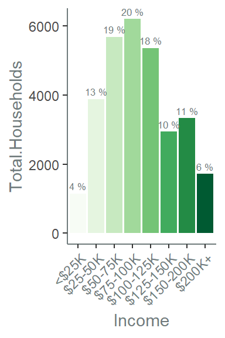

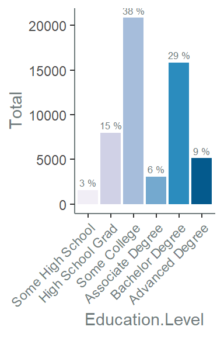

### Concentric Ring Comparisons

##### Demographics

|  | 1 Mile | 3 Mile | 5 Mile | w/ EM & SS |
| --- | --- | --- | --- | --- |
| Population | 7,918.0 | 35,376.0 | 113,756.0 | 165,068.0 |
| Population Growth Rate 2019-2024 | 14.78% | 18.86% | 19.8% | 37.43% |
| Households | 2,094 | 9,585 | 30,254 | 40,532 |
| Household Growth Rate 2019-2024 | 16.71% | 20.34% | 21.07% | 37.43% |
| Average Household Size | 3.8 | 3.7 | 3.8 | 4.2 |
| Median Household Income | $96,052 | $86,277 | $92,818 | $90,102 |
| Median Age | 20.6 | 22 | 22.7 | 22 |

##### Businesses & Schools

|  | 1 Mile | 3 Mile | 5 Mile | w/ EM & SS |
| --- | --- | --- | --- | --- |
| Number of Business (1 mile only) | 105 |  |  |  |
| Elementary Schools | 2 | 8 | 23 | 27 |
| Middle Schools | 0 | 2 | 4 | 5 |
| High Schools | 0 | 1 | 3 | 3 |
| Hospitals (Current & Announced) | 0 | 5 | 5 | 5 |

##### Dental Market

|  | 1 Mile | 3 Mile | 5 Mile | w/ EM & SS |
| --- | --- | --- | --- | --- |
| General Dentists | 9 | 17 | 37 | 38 |
| Orthodontists | 4 | 7 | 16 | 16 |
| Pediatric Dentists | 3 | 5 | 13 | 13 |
| Endodontists | 0 | 0 | 0 | 0 |
| Periodontists | 0 | 0 | 0 | 0 |
| Prosthodontists | 0 | 0 | 0 | 0 |
| Total Dental Professionals | 18 | 33 | 72 | 73 |

##### Oral Surgeon Market

|  | 1 Mile | 3 Mile | 5 Mile | w/ EM & SS |
| --- | --- | --- | --- | --- |
| Population/Oral Surgeon Ratio | 3,959.0 | 8,844.0 | 18,959.0 | 27,511.0 |
| Current Oral Surgeons | 2 | 4 | 6 | 6 |
| Estimated Demand† | 2 | 3.3 | 6.6 | 7.9 |
| Projected 5 Year Demand | 2.2 | 3.8 | 7.8 | 10.4 |

### Notable Demographic Comparisons

#### 5 mile radius

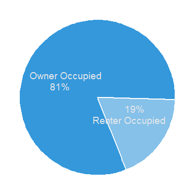

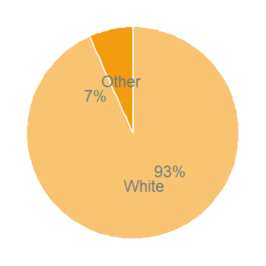

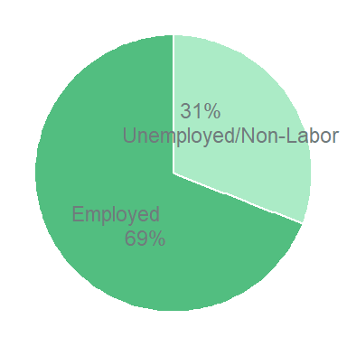

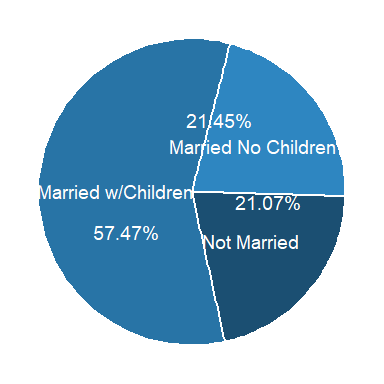

†See *About Our Analysis Process* for details on how demand is calculated.

## *About Our Analysis Process*

Optima Location Solutions employs a robust analysis process consisting of three parts:

**1. Model development**: We collect over 125 different demographic and economic variables. Each variable undergoes rigorous statistical analysis to assess which variables are predictive of successful practices in your market. Relevant variables are then used to create models that predict demand. Finally, models are statistically assessed for accuracy.

**2. Estimate demand**: Once a successful model has been developed, relevant demographic and economic variables are collected for your specific locations. These variables are combined with our predictive models to estimate market demand in each set of geography. Each location is assessed and demand estimates are reviewed to ensure that they are, indeed, relevant for you market and specific location.

**3. Report development**: Finally, we collect several notable demographic, economic, and market variables (such as competitors or symbiotic businesses) to present in a simple report format. We have taken painstaking care to present this information in a user-friendly format that presents actionable information and insights rather than a deluge of data and information. This also includes interactive Google Maps showing locations, areas of analysis, relevant data for each area, and competitor or other relevant business locations.

Please don’t hesitate to contact us with any comments or questions:

Justin Nipko

justin.nipko@gmail.com

[figure not shown]